# TF-IDF_Trump’s election speeches

Ching-Yung Chang

10/17/2018

TF-IDF_川普選前演講分析 1. 從Kaggle下載川普在總統大選前三個月的64場演講逐字稿，分析演講用字的使用頻率。

```r
library(NLP)
library(tm)
library(stats)
library(proxy)
library(dplyr)
library(readtext)
library(slam)
library(Matrix)
library(tidytext)
library(ggplot2)
```

使用readtext一次下載多個txt檔

```r
setwd("~/Documents/GitHub/CSX_RProject_Fall_2018/week_5/hw_5/hw_5_TF-IDF/trump")
rawData <- readtext("*.txt")
rawData
```

```
## readtext object consisting of 64 documents and 0 docvars.
## # data.frame [64 x 2]
##   doc_id                          text
##   <chr>                           <chr>
## 1 Trump_AshevilleNC_Sep-12-16.txt "\"This is ou\"..."
## 2 Trump_AstonPA_Sep-13-16.txt     "\"Thank you.\"..."
## 3 Trump_Austin_Aug-23-16.txt      "\"On Novembe\"..."
## 4 Trump_BaltimoreMD_Sep-12-16.txt "\"Thank you.\"..."
## 5 Trump_BangorME_Oct-15-16.txt    "\"Thank you.\"..."
## 6 Trump_BedfordNH_Sep-29-16.txt   "\"Thank you.\"..."
## # ... with 58 more rows
```

為了讓原始資料第一行(rawData$doc_id)元素更簡潔，用gsub把檔名中多餘的文字刪掉

```r
rawData$doc_id <- gsub("Trump_"," ",rawData$doc_id)
print(rawData$doc_id)
rawData$doc_id <- gsub("-16.txt"," ",rawData$doc_id)
print(rawData$doc_id)
```

建立文本資料結構與基本文字清洗，刪去標點符號、數字以及一些英文常見字詞

```r
docs <- Corpus(VectorSource(rawData$text))
toSpace <- content_transformer(function(x, pattern) {
  return(gsub(pattern, " ", x))
})
docs <- tm_map(docs, removePunctuation)
docs <- tm_map(docs, removeNumbers)
docs <- tm_map(docs, tolower)
docs <- tm_map(docs, removeWords, stopwords("english"))
docs <- tm_map(docs, stripWhitespace)
```

建立文本矩陣 TermDocumentMatrix

```r
tdm <- TermDocumentMatrix(docs)
tdm
```

```
## <<TermDocumentMatrix (terms: 7424, documents: 64)>>
## Non-/sparse entries: 45722/429414
## Sparsity           : 90%
## Maximal term length: 27
## Weighting          : term frequency (tf)
```

```r
print(tf <- as.matrix(tdm))
DF <- tidy(tf)
DF <- DF[-1, ]
```

將原始資料第一行(rawData$doc_id)的64個演講名稱，設定為向量。之後，再將新的資料(所有字詞在各場演講 出現的次數)的變數名稱，轉成自己命名的變數名稱。

```r
speech_data <- c(rawData$doc_id)
print(speech_data)
colnames(DF) <- c("", speech_data)
print(colnames(DF))
```

```r
head(DF, 5)
```

```
## # A tibble: 5 x 65
##   ``    ` AshevilleNC_S~ ` AstonPA_Sep-1~ ` Austin_Aug-23~ ` BaltimoreMD_S~
##   <chr>            <dbl>            <dbl>            <dbl>            <dbl>
## 1 able                 1                3                1                0
## 2 abra~                1                0                0                0
## 3 acce~                1                0                0                0
## 4 acco~                1                1                0                0
## 5 acco~                1                0                0                0
## # ... with 60 more variables: ` BangorME_Oct-15 ` <dbl>, `
## #   BedfordNH_Sep-29 ` <dbl>, ` Canton_Sep-14 ` <dbl>, ` Charlotte_Aug-18
## #   ` <dbl>, ` Charlotte_Oct-26 ` <dbl>, ` ChesterTownshipPA_Sep-22
## #   ` <dbl>, ` Cincinnati_Sep-1 ` <dbl>, ` Cleveland_Sep-8 ` <dbl>, `
## #   ColoradoSpringsCO_Oct-18 ` <dbl>, ` Columbus_Oct-13 ` <dbl>, `
## #   CouncilBluffsIA_Sep-28 ` <dbl>, ` DC_Sep-9 ` <dbl>, `
## #   DelawareOH_Oct-20 ` <dbl>, ` DesMoines_Sep-13 ` <dbl>, ` Detroit_Aug-8
## #   ` <dbl>, ` Detroit_Sep-3 ` <dbl>, ` DimondaleMI_Aug-19 ` <dbl>, `
## #   EriePA_Aug-12 ` <dbl>, ` EverettWA_Aug-30 ` <dbl>, ` FletcherNC_Oct-21
## #   ` <dbl>, ` Gettysburg_Oct-22 ` <dbl>, ` GoldenCO_Oct-29 ` <dbl>, `
## #   GreenBayWI_Oct-17 ` <dbl>, ` GreenBay_Aug-5 ` <dbl>, `
## #   GreenvilleNC_Sep-6 ` <dbl>, ` HendersonNV_Oct-5 ` <dbl>, `
## #   HighPointNC_Sep-20 ` <dbl>, ` Houston_Sep-17 ` <dbl>, `
## #   JacksonMS_Aug-24 ` <dbl>, ` LovelandCO_Oct-3 ` <dbl>, `
## #   ManchesterNH_Oct-28 ` <dbl>, ` MiamiFL_Nov-2 ` <dbl>, ` MiamiFL_Sep-16
## #   ` <dbl>, ` NYC_Sep-15 ` <dbl>, ` Naples_Oct-23 ` <dbl>, `
## #   NewtownPA_Oct-21 ` <dbl>, ` NoviMI_Sep-30 ` <dbl>, ` OcalaFL_Oct-12
## #   ` <dbl>, ` Orlando_Nov-2 ` <dbl>, ` PanamaCityFL_Oct-11 ` <dbl>, `
## #   PensacolaFL_Sep-9 ` <dbl>, ` Philadelphia_Sep-7 ` <dbl>, `
## #   Phoenix_Aug-31 ` <dbl>, ` Phoenix_Oct-29 ` <dbl>, ` Pittsburgh_Sep-22
## #   ` <dbl>, ` PortsmouthNH_Oct-15 ` <dbl>, ` PrescottValleyAZ_Oct-4
## #   ` <dbl>, ` PuebloCO_Oct-3 ` <dbl>, ` RaleighNC_Nov-7 ` <dbl>, `
## #   RenoNV_Oct-5 ` <dbl>, ` RoanokeVA_Sep-24 ` <dbl>, `
## #   SpringfieldOH_Oct-27 ` <dbl>, ` ValleyForgePA_Nov-1 ` <dbl>, `
## #   WarrenMI_Oct-31 ` <dbl>, ` WaukeshaWI_Sep-28 ` <dbl>, `
## #   WestBendWI_Aug-16 ` <dbl>, ` WestPalmBeach_Oct-13 ` <dbl>, `
## #   WilmingtonNC_Aug-9 ` <dbl>, ` WilmingtonOH_Sep-1 ` <dbl>, `
## #   Youngstown_Aug-15 ` <dbl>
```

```r
tail(DF, 5)
```

```
## # A tibble: 5 x 65
##   ``    ` AshevilleNC_S~ ` AstonPA_Sep-1~ ` Austin_Aug-23~ ` BaltimoreMD_S~
##   <chr>            <dbl>            <dbl>            <dbl>            <dbl>
## 1 warz~                0                0                0                0
## 2 wayw~                0                0                0                0
## 3 west~                0                0                0                0
## 4 whom~                0                0                0                0
## 5 youin                0                0                0                0
## # ... with 60 more variables: ` BangorME_Oct-15 ` <dbl>, `
## #   BedfordNH_Sep-29 ` <dbl>, ` Canton_Sep-14 ` <dbl>, ` Charlotte_Aug-18
## #   ` <dbl>, ` Charlotte_Oct-26 ` <dbl>, ` ChesterTownshipPA_Sep-22
## #   ` <dbl>, ` Cincinnati_Sep-1 ` <dbl>, ` Cleveland_Sep-8 ` <dbl>, `
## #   ColoradoSpringsCO_Oct-18 ` <dbl>, ` Columbus_Oct-13 ` <dbl>, `
## #   CouncilBluffsIA_Sep-28 ` <dbl>, ` DC_Sep-9 ` <dbl>, `
## #   DelawareOH_Oct-20 ` <dbl>, ` DesMoines_Sep-13 ` <dbl>, ` Detroit_Aug-8
## #   ` <dbl>, ` Detroit_Sep-3 ` <dbl>, ` DimondaleMI_Aug-19 ` <dbl>, `
## #   EriePA_Aug-12 ` <dbl>, ` EverettWA_Aug-30 ` <dbl>, ` FletcherNC_Oct-21
## #   ` <dbl>, ` Gettysburg_Oct-22 ` <dbl>, ` GoldenCO_Oct-29 ` <dbl>, `
## #   GreenBayWI_Oct-17 ` <dbl>, ` GreenBay_Aug-5 ` <dbl>, `
## #   GreenvilleNC_Sep-6 ` <dbl>, ` HendersonNV_Oct-5 ` <dbl>, `
## #   HighPointNC_Sep-20 ` <dbl>, ` Houston_Sep-17 ` <dbl>, `
## #   JacksonMS_Aug-24 ` <dbl>, ` LovelandCO_Oct-3 ` <dbl>, `
## #   ManchesterNH_Oct-28 ` <dbl>, ` MiamiFL_Nov-2 ` <dbl>, ` MiamiFL_Sep-16
## #   ` <dbl>, ` NYC_Sep-15 ` <dbl>, ` Naples_Oct-23 ` <dbl>, `
## #   NewtownPA_Oct-21 ` <dbl>, ` NoviMI_Sep-30 ` <dbl>, ` OcalaFL_Oct-12
## #   ` <dbl>, ` Orlando_Nov-2 ` <dbl>, ` PanamaCityFL_Oct-11 ` <dbl>, `
## #   PensacolaFL_Sep-9 ` <dbl>, ` Philadelphia_Sep-7 ` <dbl>, `
## #   Phoenix_Aug-31 ` <dbl>, ` Phoenix_Oct-29 ` <dbl>, ` Pittsburgh_Sep-22
## #   ` <dbl>, ` PortsmouthNH_Oct-15 ` <dbl>, ` PrescottValleyAZ_Oct-4
## #   ` <dbl>, ` PuebloCO_Oct-3 ` <dbl>, ` RaleighNC_Nov-7 ` <dbl>, `
## #   RenoNV_Oct-5 ` <dbl>, ` RoanokeVA_Sep-24 ` <dbl>, `
## #   SpringfieldOH_Oct-27 ` <dbl>, ` ValleyForgePA_Nov-1 ` <dbl>, `
## #   WarrenMI_Oct-31 ` <dbl>, ` WaukeshaWI_Sep-28 ` <dbl>, `
## #   WestBendWI_Aug-16 ` <dbl>, ` WestPalmBeach_Oct-13 ` <dbl>, `
## #   WilmingtonNC_Aug-9 ` <dbl>, ` WilmingtonOH_Sep-1 ` <dbl>, `
## #   Youngstown_Aug-15 ` <dbl>
```

將已建好的 TDM 轉成 TF-IDF

```r
tf <- apply(tdm, 2, sum)
idfCal <- function(word_doc){log2((length(word_doc)+1) / nnzero(word_doc))}
idf <- apply(tdm, 1, idfCal)
doc.tfidf <- as.matrix(tdm)
doc.tfidf[ ,-1]
for(i in 1:nrow(tdm)){
  for(j in 1:ncol(tdm)){
    doc.tfidf[i,j] <- (doc.tfidf[i,j] / tf[j]) * idf[i]
  }
}

findZeroId <- as.matrix(apply(doc.tfidf, 1, sum))
tfidfnn <- doc.tfidf[-which(findZeroId == 0),]

write.csv(tfidfnn, "show.csv")


colnames(doc.tfidf) <- speech_data
print(colnames(doc.tfidf))
```

計算新資料的前十列、後十列文字，在所有演講出現的次數

```r
termFrequency = rowSums(as.matrix(tdm))
termFrequency = subset(termFrequency, termFrequency>=10)

df = data.frame(term=names(termFrequency), freq=termFrequency)
head(termFrequency,10)
```

```
##       abandoned            able      accomplish         achieve
##              10              54              50              15
##  administration        admirals africanamerican             age
##             170              12             144              25
##          agenda            also
##              48             377
```

```r
tail(termFrequency,10)
```

```
##        putin      custody       killer     murdered      shooter
##           19           11           10           14           16
##         rudy technologies         firm      premium         navy
##           12           10           12           15           20
```

找出所有演講中，出現次數最高的30個字詞

```r
high.freq=tail(sort(termFrequency),n=30)
hfp.df=as.data.frame(sort(high.freq))
hfp.df$names <- rownames(hfp.df)
```

畫柱狀圖，顯示出現次數最高的30個字，各別出現的次數

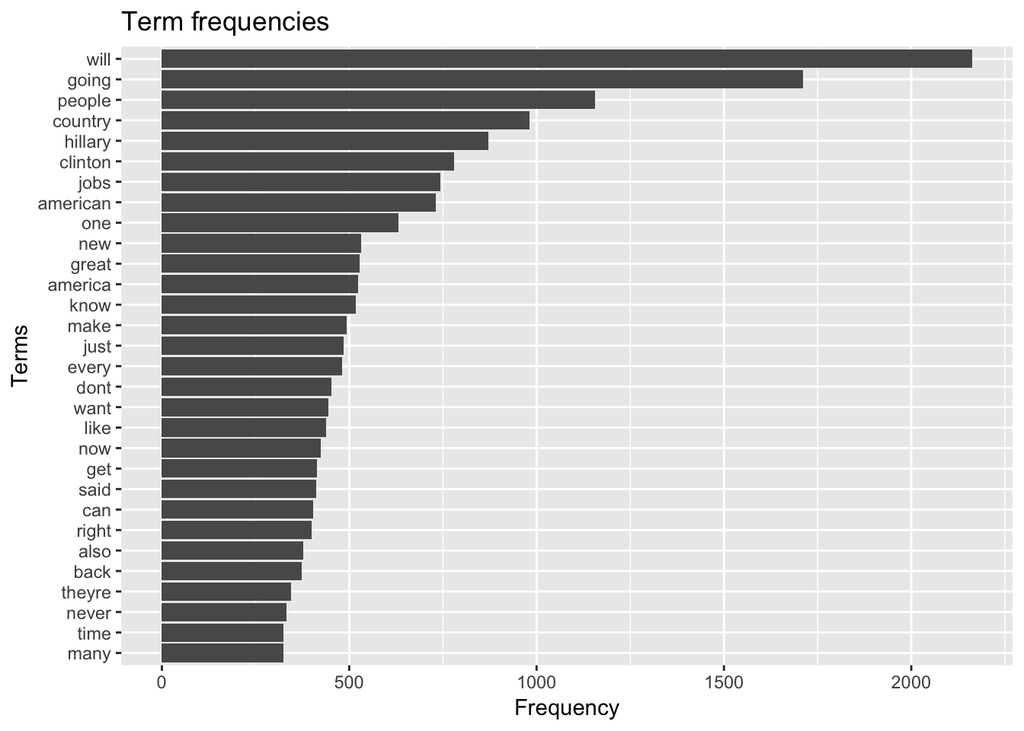

```r
library(knitr)
library(ggplot2)
# png('Trump_speeches.png')

ggplot(hfp.df, aes(reorder(names,high.freq), high.freq)) +
  geom_bar(stat="identity") + coord_flip() +
  xlab("Terms") + ylab("Frequency") +
  ggtitle("Term frequencies")
```

接著找出次數最高的50個字詞

```r
high.freq_1=tail(sort(termFrequency),n=50)
hfp.df_1=as.data.frame(sort(high.freq_1))
hfp.df_1$names <- rownames(hfp.df_1)
```

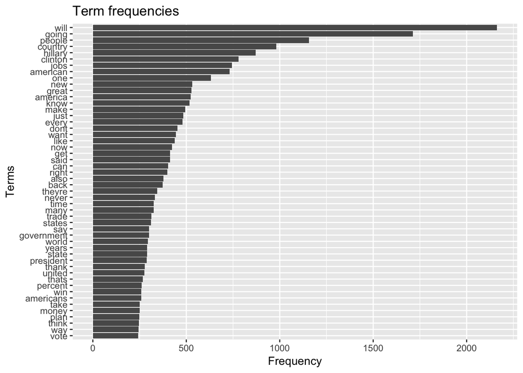

```r
library(knitr)
library(ggplot2)
# png('Trump_speeches.png')

ggplot(hfp.df_1, aes(reorder(names,high.freq_1), high.freq_1)) +
  geom_bar(stat="identity") + coord_flip() +
  xlab("Terms") + ylab("Frequency") +
  ggtitle("Term frequencies")
```

結論：在這些演講中，扣除will、going、one、just等常見的字詞，川普較常提到的字詞包含people、country、 hillary clinton、jobs、america/american等，而這些詞也正是候選人在演講中常提到的詞。上述情形 是最常使用的30個字，一旦把範圍拉到最常使用的50個字詞，此時多出了trade、government、money、 plan等詞，比較值得注意的詞大概就是trade，最近幾個月鬧得沸沸揚揚的中美貿易戰，也許能呼應川普 在演講時提到有關貿易的政策。